## Advanced Data Analysis HW5

## Name: Yan Wu Uni: yw2592

**Problem 1**

```r
require(MASS)
```

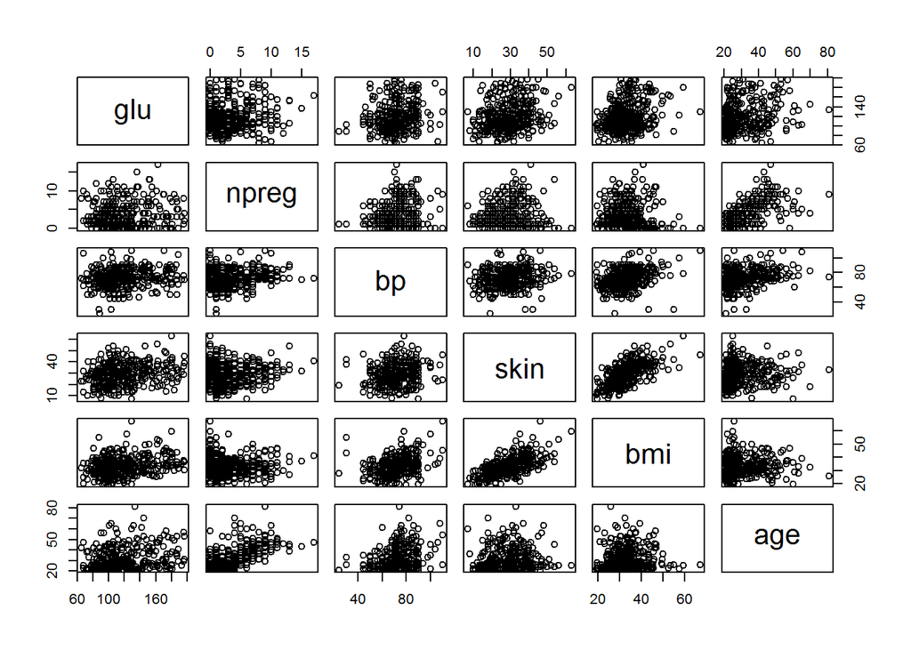

```r
data <- Pima.te
pairs(~glu+npreg+bp+skin+bmi+age,data=data)
```

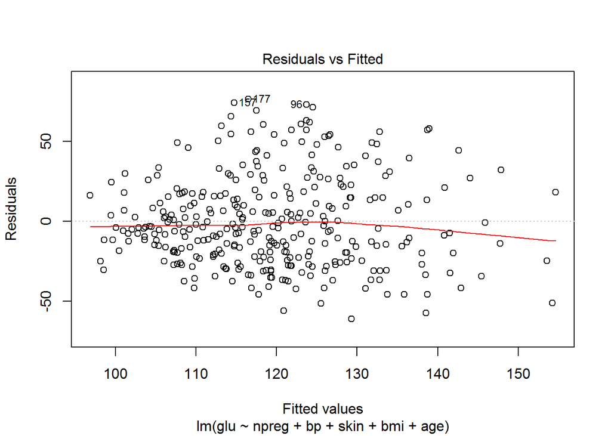

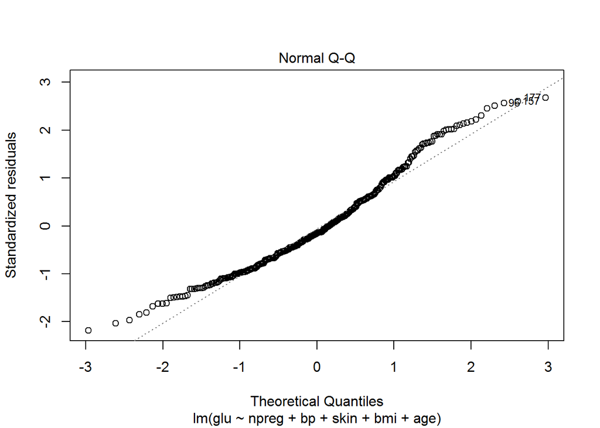

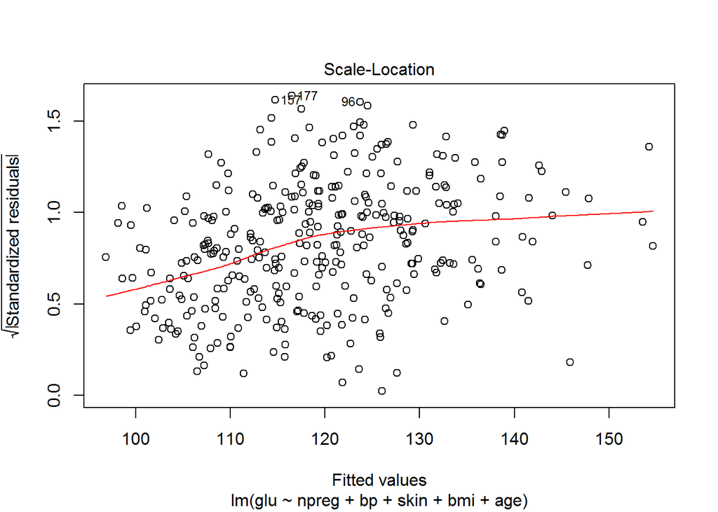

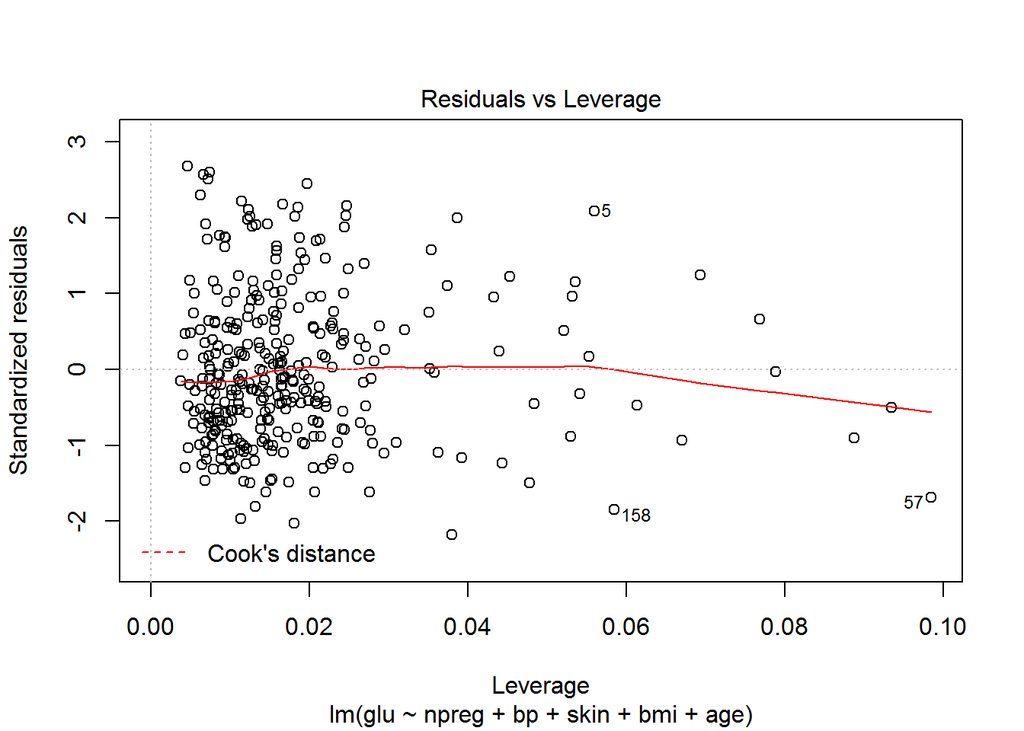

```r
fit1 <- lm(glu~npreg+bp+skin+bmi+age,data=data)
plot(fit1)
```

```r
summary(fit1)
```

```
##
## Call:
## lm(formula = glu ~ npreg + bp + skin + bmi + age, data = data)
##
## Residuals:
##    Min     1Q Median     3Q    Max
## -61.29 -20.56  -4.36  17.37  76.51
##
## Coefficients:
##             Estimate Std. Error t value Pr(>|t|)
## (Intercept)   56.831     10.309    5.51  7.2e-08 ***
## npreg         -0.875      0.647   -1.35  0.17735
## bp             0.104      0.138    0.75  0.45353
## skin           0.263      0.216    1.21  0.22575
## bmi            0.796      0.302    2.64  0.00880 **
## age            0.764      0.207    3.69  0.00026 ***
## ---
## Signif. codes:  0 '***' 0.001 '**' 0.01 '*' 0.05 '.' 0.1 ' ' 1
##
## Residual standard error: 28.6 on 326 degrees of freedom
## Multiple R-squared:  0.134,  Adjusted R-squared:  0.121
## F-statistic: 10.1 on 5 and 326 DF,  p-value: 5.58e-09
```

From the result of the fitted model, we have the average estimates of efficiences. The linear regression model is glu = 56.831-0.875npreg+0.104bp+0.263skin+0.796bmi+0.764age.

**Problem2**

- **Nonlinearity Check**

```r
summary(fit1)$r.squared
```

```
## [1] 0.1338
```

Since the R-squared is only 0.1338033, really small, which means there are a lot of variance is not explained by the model. It suggests the fitted model suffers from the lack of fit.

- **Normality Check**

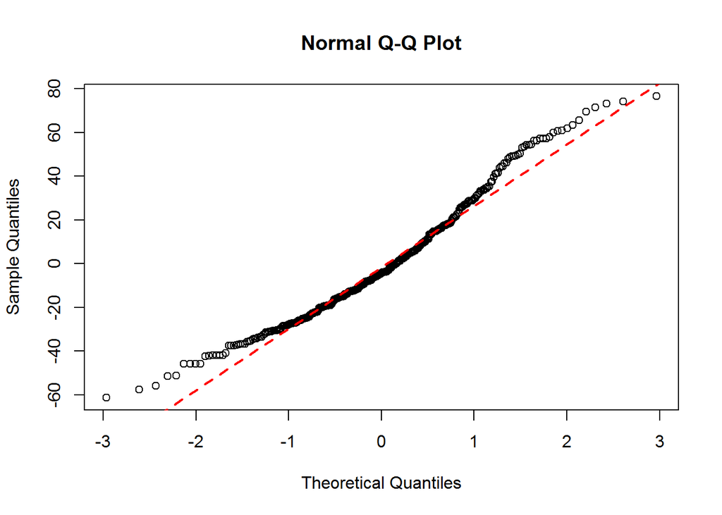

```r
qqnorm(fit1$residuals)
qqline(fit1$residuals,col = 2,lwd=2,lty=2)
```

```r
st <- shapiro.test(fit1$residuals)
st
```

```
##
##  Shapiro-Wilk normality test
##
## data:  fit1$residuals
## W = 0.9703, p-value = 2.532e-06
```

```r
st$p.value
```

```
## [1] 2.532e-06
```

Since the p-value from Shapiro-Wilk test is significantly small, we could conclude that the sample deviates from normality.

- **Homoscedasticity Check**

The plot of the residuals against the fitted values is also helpful to examine the homoscedasicity of the error term.

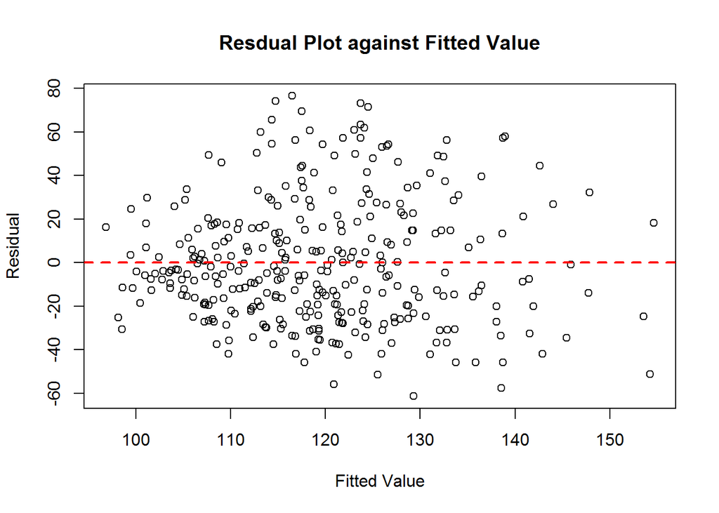

```r
plot(fit1$fitted.values,fit1$residuals,xlab='Fitted Value',ylab='Residual',main="Resdual Plot against Fitted Value")
abline(h=0,col = 2,lwd=2,lty=2)
```

- **Uncorrelated Error Check**

```r
require(lmtest)
dw <- dwtest(fit1)
dw
```

```
##
##  Durbin-Watson test
##
## data:  fit1
## DW = 1.938, p-value = 0.2847
## alternative hypothesis: true autocorrelation is greater than 0
```

```r
dw$p.value
```

```
## [1] 0.2847
```

- **Outliers**

```r
###Examine outlying Y observations
n = nrow(data)
elist = fit1$resi
p = 6
SSE = sum(elist^2)
X = cbind(1,data$npreg,data$bp,data$skin,data$bmi,data$age)
hlist = diag(X%*%solve(t(X)%*%X)%*%t(X))
tlist = elist*((n-p-1)/(SSE*(1-hlist)-elist^2))^(1/2)
max(abs(tlist))
```

```
## [1] 2.707
```

```r
which(abs(tlist)==max(abs(tlist)))
```

```
## 177
## 177
```

```r
qt(0.9975,n-p-1)
```

```
## [1] 2.826
```

```r
###Identifying outlying X observations with Hat Matrix Leverage Values
2*p/n
```

```
## [1] 0.03614
```

```r
which(hlist > 2*p/n)
```

```
##  [1]   5   8  12  18  21  41  43  57  72  79  92 107 141 158 196 198 203
## [18] 211 217 232 249 262 287 291 292 320 330
```

From the result, we could identify the outliers of X.

- **Influential Points**

```r
lmi <- lm.influence(fit1)
lms <- summary(fit1)
e <- resid(fit1)
s <- lms$sigma
si <- lmi$sigma
xxi <- diag(lms$cov.unscaled)
h <- lmi$hat
bi <- coef(fit1)-t(coef(lmi))
dfbetas <- bi/t(si%o%xxi^0.5)
stand.resid <- e/(si*(1-h)^0.5)
DFFITS <- h^0.5*e/(si*(1-h))
which(abs(stand.resid)>2*sqrt(p/n))
```

[output not shown]

**Problem 3. The remedial measures in case of violations of any of the underlying assumptions**

- **Lack of fit:** 1) Simple trasformations, e.g, take log; 2)Non-linear model; 3)Other predictors.
- **Non-constancy:** 1) Transformation; 2) Build variance structure in to model: WLS.
- **Non-Normality:** 1) Transformation; 2)Robust regression methods.
- **Correlated Errors:**1) Transformation: Cochrane-Crutt Procedure. 2) Use models that incorporate the correlattion structure: Generalized Estimating Equations
- **Multicollinearity:** Ridge regression
- **Influential Cases:** Robust regression

From problem 2, we know the nonlinearity, non-normality, and influential cases exist. We could use proposal of remedial measures above to fix problems.